# Reproducible MLE Algorithm

drafly

Tuesday, May 12, 2015

## 多重伯努利实验下的最大似然估计

似然函数：产生某序列的概率: $ll = p^k * (1 - p)^(n - k)$

```r
likelihood <- function(sequence, p.parameter)
{
  likelihood <- 1
  num <- 0
  for (i in 1:length(sequence))
  {
    if (sequence[i] == 1)
    {
      likelihood <- likelihood * p.parameter
      num <- num + 1
    }
    else
    {
      likelihood <- likelihood * (1 - p.parameter)
    }
  }
  likelihood <- likelihood
  return(likelihood)
}
```

生成多重伯努利实验序列：

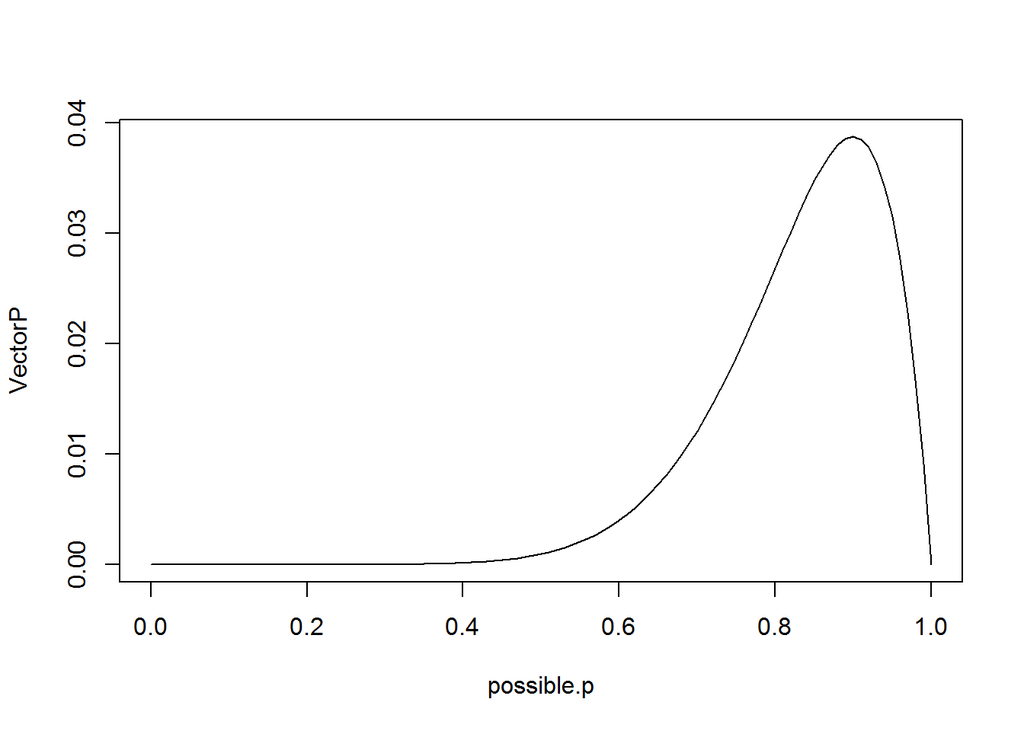

```
##  [1] "产生的序列为1" "产生的序列为1" "产生的序列为1" "产生的序列为1"
##  [5] "产生的序列为1" "产生的序列为1" "产生的序列为0" "产生的序列为1"
##  [9] "产生的序列为1" "产生的序列为1"
```

```
## [1] "最优值为序列均值：0.9"
```

这里我们采用MLE对产生序列的最大可能的似然函数的概率进行求解：

```r
#采用optimize优化方法寻优
mle.results <- optimize(function(p) {likelihood(sequence, p)},
                        interval = c(0, 1),
                        maximum = TRUE)
print(sprintf("optimize()函数优化结果为：%g", mle.results$maximum))
```

```
## [1] "optimize()函数优化结果为：0.899998"
```

对于预测结果的误差进行计算：

```r
#计算不同数量序列下估计的误差
error.behavior <- data.frame()
findSample <- seq(100, 2500, 100)
for (n in findSample)
{
  sequence <- rbinom(n, 1, p.parameter)
  likelihood.results <- optimize(function(p) {likelihood(sequence, p)},
                                 interval = c(0, 1),
                                 maximum = TRUE)
  true.mle <- mean(sequence)
  likelihood.error <- true.mle - likelihood.results$maximum
  error.behavior <- rbind(error.behavior,
                          data.frame(N = n,
                                     Error = likelihood.error,
                                     Algorithm = 'Likelihood'))
}
```

计算结果如下：

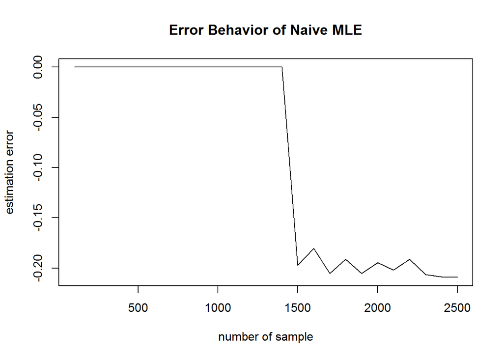

```
## [1] "the sample is 2500, and the likelihood is 0.999934"
```

```r
log.likelihood <- function(sequence, p)
{
  log.likelihood <- 0
  for (i in 1:length(sequence))
  {
    if (sequence[i] == 1)
    {
      log.likelihood <- log.likelihood + log(p)
    }
    else
    {
      log.likelihood <- log.likelihood + log(1 - p)
    }
  }
  return(log.likelihood)
}
```

重新计算最大似然估计的误差：

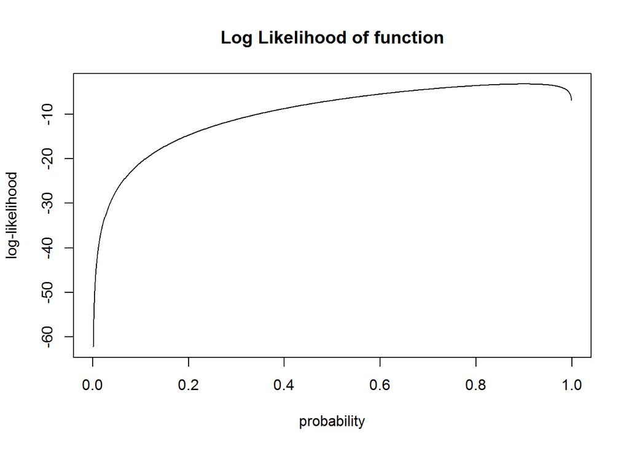

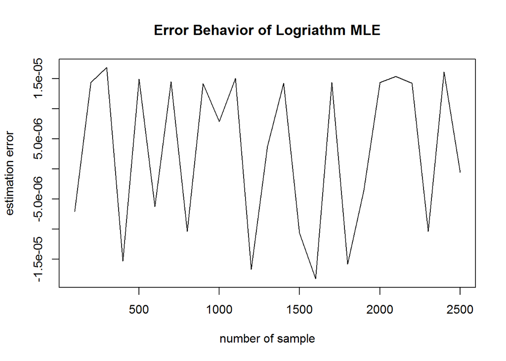

[output not shown]

总结，最大似然估计求解的伪代码如下：

```r
##最大似然函数的伪代码
log.likelihood <- function(sequence.as.data.frame, likelihood.function, parameters)
{
  log.likelihood <- 0

  for (i in 1:nrow(sequence.as.data.frame))
  {
    log.likelihood <- log.likelihood + log(likelihood.function(
      sequence.as.data.frame[i,], parameters))
  }

  return(log.likelihood)
}
```

## 最大似然估计求解logistic回归

对于logistic回归而言，分类结果的表达式如下： $p(y=1|x,theta)=exp(beta*x)/(1+exp(beta*x))$; 和$p(y=0|x,theta)=1/(1+exp(beta*x))$ 所以，为采用MLE求解logistics回归参数，需要定义似然函数。为获得产生样本的最大可能，根据贝叶斯误差，对于所有样本，$p(y=1|x,theta)$或者$p(y=0|x,theta)$要尽可能最大。 所以对于单一样本，似然函数可定义为:$ll = - y*p(y=1|x,theta) - (1-y)*p(y=0|x,theta)$ 之前博客中提到的数值分析中的optimize()函数适用于一维的优化问题，多维度优化问题应当采用optim()函数。本实例采用iris数据做二分类，并分别在给定梯度和未给定梯度的情况下，两种优化方法的求解过程。

对iris数据的展示：

```
## 'data.frame':    150 obs. of  5 variables:
##  $ Sepal.Length: num  5.1 4.9 4.7 4.6 5 5.4 4.6 5 4.4 4.9 ...
##  $ Sepal.Width : num  3.5 3 3.2 3.1 3.6 3.9 3.4 3.4 2.9 3.1 ...
##  $ Petal.Length: num  1.4 1.4 1.3 1.5 1.4 1.7 1.4 1.5 1.4 1.5 ...
##  $ Petal.Width : num  0.2 0.2 0.2 0.2 0.2 0.4 0.3 0.2 0.2 0.1 ...
##  $ Species     : num  1 1 1 1 1 1 1 1 1 1 ...
```

编写logistic回归的似然函数：

```r
lr.log.likelihood <- function(x, para){
  log.likelihood <- 0
  RlenX <- length(x[1,])
  intervalX <- rep(1, RlenX)
  x <- cbind(intervalX, x)
  ClenX <- length(x[1,])

  for (i in 1:length(x[ ,1]))
  {
    log.likelihood <- log.likelihood -
      x[i,ClenX] * log(exp(as.matrix(x[i,1:(ClenX-1)]) %*% as.matrix(para)) / (1+exp(as.matrix(x[i,1:(ClenX-1)]) %*% as.matrix(para)))) - (1-x[i,ClenX]) * log(1/(1+exp(as.matrix(x[i,1:(ClenX-1)]) %*% as.matrix(para))))
  }
  log.likelihood <- log.likelihood / length(x[,1])
  return(log.likelihood)
}
```

采用NM算法对似然函数进行优化求解：

```r
##给定初始参数
initPara <- c(0.5, 3, 1.0, 2.0, 1)
lr.mle.results <- optim(par = initPara,fn = function(p) {lr.log.likelihood(irisData, p)},
                        method = "Nelder-Mead",  #或者采用SANN方法
                        control = list(trace = TRUE, maxit = 100))
```

```
##   Nelder-Mead direct search function minimizer
## function value for initial parameters = 22.430667
##   Scaled convergence tolerance is 3.34243e-07
## Stepsize computed as 0.300000
## BUILD              6 23.683067 22.430667
## EXTENSION          8 23.411867 21.180347
## LO-REDUCTION      10 23.005067 21.180347
## EXTENSION         12 22.765867 20.230302
## LO-REDUCTION      14 22.630667 20.230302
## EXTENSION         16 22.430667 18.107482
## EXTENSION         18 21.393179 15.913571
## LO-REDUCTION      20 21.180347 15.913571
## EXTENSION         22 20.380198 12.577215
## LO-REDUCTION      24 20.230302 12.577215
## EXTENSION         26 18.107482 5.680914
## LO-REDUCTION      28 16.931581 5.680914
## EXTENSION         30 15.913571 2.549338
## LO-REDUCTION      32 13.123885 2.549338
## LO-REDUCTION      34 12.577215 2.549338
## LO-REDUCTION      36 7.552867 2.549338
## LO-REDUCTION      38 5.680914 2.549338
## LO-REDUCTION      40 4.095650 2.549338
## LO-REDUCTION      42 3.351352 2.549338
## LO-REDUCTION      44 3.319691 2.549338
## HI-REDUCTION      46 2.927015 2.549338
## EXTENSION         48 2.870662 2.391360
## HI-REDUCTION      50 2.838036 2.391360
## EXTENSION         52 2.730175 2.121848
## LO-REDUCTION      54 2.725207 2.121848
## LO-REDUCTION      56 2.648231 2.121848
## EXTENSION         58 2.549338 1.277499
## LO-REDUCTION      60 2.391360 1.277499
## LO-REDUCTION      62 2.134173 1.277499
## EXTENSION         64 2.126805 0.899268
## EXTENSION         66 2.121848 0.738003
## EXTENSION         68 1.739583 0.497420
## LO-REDUCTION      70 1.390632 0.497420
## EXTENSION         72 1.277499 0.242778
## LO-REDUCTION      74 0.899268 0.242778
## HI-REDUCTION      76 0.738003 0.242778
## LO-REDUCTION      78 0.705120 0.242778
## EXTENSION         80 0.497420 0.091090
## LO-REDUCTION      82 0.434103 0.091090
## EXTENSION         84 0.425322 0.020799
## LO-REDUCTION      86 0.257426 0.020799
## LO-REDUCTION      88 0.242778 0.020799
## EXTENSION         90 0.100227 0.003329
## LO-REDUCTION      92 0.091090 0.003329
## EXTENSION         94 0.061686 0.000704
## EXTENSION         96 0.023683 0.000082
## LO-REDUCTION      98 0.020799 0.000082
## EXTENSION        100 0.009251 0.000005
## Exiting from Nelder Mead minimizer
##     102 function evaluations used
```

```r
#打印错误日志
if (lr.mle.results$convergence == 1){
  print("ATTENTION: the iteration limit maxit had been reached!!")
}
```

```
## [1] "ATTENTION: the iteration limit maxit had been reached!!"
```

```r
if (lr.mle.results$convergence == 10){
  print("ATTENTION: degeneracy of the Nelder–Mead simplex!!")
}
if (lr.mle.results$convergence == 0){
  print("ATTENTION: successful completion!!")
}
```

接下来预测分类标签：

```
##         predicted
## observed   0   1
##        0 100   0
##        1   0  50
```

如果改用梯度下降算法进行求解，则可使用BFGS下降算法：

```r
#给定梯度，采用BFGS算法求解
bfgs.likelihood <- function(x, para){
  log.likelihood <- 0
  RlenX <- length(x[1,])
  intervalX <- rep(1, RlenX)
  x <- cbind(intervalX, x)
  ClenX <- length(x[1,])

  for (i in 1:length(x[ ,1]))
  {
    log.likelihood <- log.likelihood -
      x[i,ClenX] * log(exp(as.matrix(x[i,1:(ClenX-1)]) %*% as.matrix(para)) / (1+exp(as.matrix(x[i,1:(ClenX-1)]) %*% as.matrix(para)))) - (1-x[i,ClenX]) * log(1/(1+exp(as.matrix(x[i,1:(ClenX-1)]) %*% as.matrix(para))))
  }
  log.likelihood <- log.likelihood / length(x[,1])
  return(log.likelihood)
}

gr.log.likelihood <- function(x, para){
  RlenX <- length(x[1,])
#  p <- 1/(1 + exp(as.matrix(-x) %*% as.matrix(para)))
#  -(crossprod(as.matrix(x),as.matrix(x[,RlenX] - p)))
   gr.likelihood <- rep(0, length(para))
   intervalX <- rep(1, RlenX)
   x <- cbind(intervalX, x)
   ClenX <- length(x[1,])
   for (j in 1:length(para)){
     for (i in 1:length(x[ ,1]))
     {
       gr.likelihood[j] <- gr.likelihood[j] +
         x[i,j] * (exp(as.matrix(x[i,1:(ClenX-1)]) %*% as.matrix(para))/(1 + exp(as.matrix(x[i,1:(ClenX-1)]) %*% as.matrix(para))) - x[i,ClenX])
     }
   }
   gr.likelihood <- gr.likelihood / length(x[,1])
#   return(gr.likelihood)
}

lr.bfgs.results <- optim(par = initPara,
                        fn = function(p) {bfgs.likelihood(irisData, p)},
                        gr = function(p) {gr.log.likelihood(irisData, p)},
                        method = "L-BFGS-B", #L-BFGS-B
                        control = list(trace = TRUE, maxit = 100))
#打印错误日志
if (lr.bfgs.results$convergence == 51 | lr.bfgs.results$convergence == 52){
  print(lr.bfgs.results$message)
}
```

查看分类预测结果：

```
##         predicted
## observed   0   1
##        0 100   0
##        1   0  50
```

对比两次迭代运算结果：

```
## $par
## [1]   8.949999 -10.264483  32.409531 -19.092773  11.111725
##
## $value
## [1] 5.098613e-06
##
## $counts
## function gradient
##      102       NA
##
## $convergence
## [1] 1
##
## $message
## NULL
```

```
## $par
## [1]   2.313920   3.925389   9.658279 -17.749835  -8.449813
##
## $value
## [1] 1.232823e-09
##
## $counts
## function gradient
##       39       39
##
## $convergence
## [1] 0
##
## $message
## [1] "CONVERGENCE: REL_REDUCTION_OF_F <= FACTR*EPSMCH"
```

```
## [1] "Nelder-Mead和BFGS两种方法迭代次数分别为：102 和 39"
```

最后采用stats包中的glm函数iris数据进行分类建模，并给出预测结果：

```
##
## Call:  glm(formula = Species ~ ., family = binomial, data = irisGlm)
##
## Coefficients:
##  (Intercept)  Sepal.Length   Sepal.Width  Petal.Length   Petal.Width
##      -16.946        11.759         7.842       -20.088       -21.608
##
## Degrees of Freedom: 149 Total (i.e. Null);  145 Residual
## Null Deviance:       191
## Residual Deviance: 3.294e-09     AIC: 10
```

```
##         predicted
## observed   0   1
##        0 100   0
##        1   0  50
```